# Homework.5

Jose Nieves

February 26, 2016

# INTD 8065 Data Analysis for Cancer Research

# Homework #5

1. Run the t test for the comparison of control diet and high fat diet presented in page 51-52 of Irizarry and Love (2015) assuming equality ofvariances.

Compare your result with that of the analysis obtained in the book.

```r
library(dplyr)
library(downloader)
url <- "https://raw.githubusercontent.com/genomicsclass/dagdata/master/inst/
        extdata/femaleMiceWeights.csv"
filename <- "femaleMiceWeights.csv"
if (!file.exists(filename)) download(url, destfile=filename)
femaleMiceWeights <-read.csv(filename)

control <- filter(femaleMiceWeights,Diet=="chow") %>% select(Bodyweight) %>% unlist
treatment <- filter(femaleMiceWeights,Diet=="hf") %>% select(Bodyweight) %>% unlist

t.test(treatment, control, var.equal = TRUE)
```

```
##
##  Two Sample t-test
##
## data:  treatment and control
## t = 2.0552, df = 22, p-value = 0.05192
## alternative hypothesis: true difference in means is not equal to 0
## 95 percent confidence interval:
##  -0.02748516  6.06915183
## sample estimates:
## mean of x mean of y
##  26.83417  23.81333
```

```r
t.test(treatment, control)
```

```
##
##  Welch Two Sample t-test
##
## data:  treatment and control
## t = 2.0552, df = 20.236, p-value = 0.053
## alternative hypothesis: true difference in means is not equal to 0
## 95 percent confidence interval:
##  -0.04296563  6.08463229
## sample estimates:
## mean of x mean of y
##  26.83417  23.81333
```

In what follows, we will use library (pwr) mentioned in Irizarry and Love (2015), page 64.

2. Download and install the library.

```r
library(pwr)
```

3. Use the function power.t.test in library pwr for calculating the power obtained by simulation in page 64 by Irizarry and Love for N=12 and alpha = 0.05.

Use delta as the real difference between the population means. Assume the standard deviations of the two populations are equal and calculate it as

sd <- sqrt(((n1-1)*var(hfPopulation)+(n2-1)*var(controlPopulation))/(n1+n2))

where n1 and n2 are the sizes of hfPopulation and controlPopulation, respectively

```r
url <- "https://raw.githubusercontent.com/genomicsclass/dagdata/master/inst/
        extdata/mice_pheno.csv"
filename <- "mice_pheno.csv"
if (!file.exists(filename)) download(url, destfile=filename)
mice_pheno <- read.csv(filename)

controlPopulation <- filter(mice_pheno,Sex == "F" & Diet == "chow") %>%
                select(Bodyweight) %>% unlist
hfPopulation <- filter(mice_pheno,Sex == "F" & Diet == "hf") %>%
                select(Bodyweight) %>% unlist

N <- 12
alpha <- 0.05
B <- 2000
n1 <- nrow(filter(mice_pheno,Sex == "F" & Diet == "hf"))
n2 <- nrow(filter(mice_pheno,Sex == "F" & Diet == "chow"))
sd <- sqrt(((n1-1)*var(hfPopulation)+(n2-1)*var(controlPopulation))/(n1+n2))

power.t <- power.t.test(12, delta = TRUE, sd, sig.level = alpha, power = NULL)
print(power.t$power)
```

```
## [1] 0.07904158
```

Hint: You can pass a vector of N’s to the function, and extract the power values from the object you created using object$power. For overimposing your results, you can use the command line with the option type=”b”.

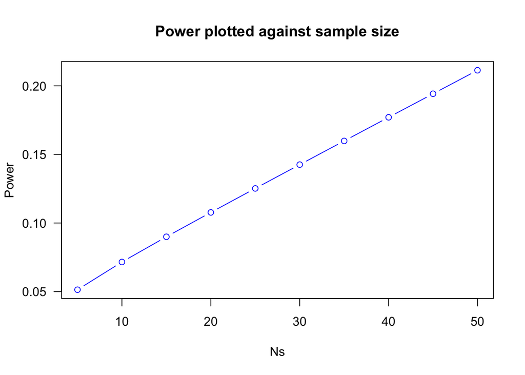

5. Repeat part 3. for the graph of power for different values of alphas shown in page 67.

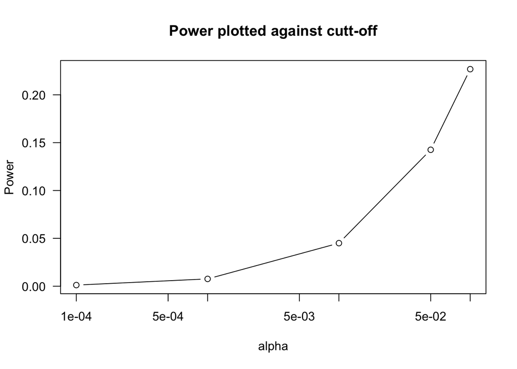

6. In this setting, use power.t.test for calculating the sample sizes for obtaining powers of 0.25, 0.5, 0.75 and 0.85. Use a = 0.05 and a = 0.01. Comment your results.

```r
Power.t.test <- function(n=NULL, delta=NULL, sd=1, sig.level=0.05,
                power=NULL, type="two.sample",
                alternative = "two.sided",
                strict=FALSE){

        if (sum(sapply(list(n, delta, power), is.null)) != 1)
                stop("Exactly one of 'n', 'delta', and 'power' may be NULL")

        extract <- names(which(sapply(list(n=n, delta=delta, power=power), is.null)))

        Power <- expand.grid(n = if (is.null(n)) NA else n,
                        delta = if (is.null(delta)) NA else delta,
                        sd = sd,
                        sig.level = sig.level,
                        power = if (is.null(power)) NA else power,
                        type = type,
                        alternative = alternative,
                        strict = strict,
                        stringsAsFactors=FALSE)
        for (i in 1:nrow(Power)){
                Power[[extract]][i] <- with(Power, power.t.test(n = if (is.na(n[i])) NULL else n[i],
                                delta = if (is.na(delta[i])) NULL else delta[i],
                                sd = sd[i],
                                sig.level = sig.level[i],
                                power = if (is.na(power[i])) NULL else power[i],
                                type = type[i],
                                alternative = alternative[i],
                                strict = strict[i]))[[extract]]
        }

        return(Power)

}
```

vectors for powers and alphas

```r
powers.2 <- c(0.25,0.5,0.75,0.85)
alphas.2 <- c(0.05, 0.01)
```

power.t.test to find n using a = 0.05, 0.01 & powers 0.25,0.5,0.75,0.85

```r
n.pwr.t <- Power.t.test(n = NULL, delta = T, sd = sd, sig.level = alphas.2,
                power = powers.2)
keeps <- c("n", "sig.level", "power")
n.pwr.t[keeps]
```

```
##           n sig.level power
## 1  61.36856      0.05  0.25
## 2 133.79652      0.01  0.25
## 3 141.37210      0.05  0.50
## 4 244.16971      0.01  0.50
## 5 254.63523      0.05  0.75
## 6 387.79956      0.01  0.75
## 7 329.12586      0.05  0.85
## 8 478.58524      0.01  0.85
```